# MOLB 7621 Final Project

Ryan Mackie

## Hypothesis / Question

Using TCGA thryroid cancer data, is there a difference in PDL1 mRNA expression based on BRAF/RAS mutation status?

## Data

TCGA has a large amount of data from primary tumors, grouped by cancer type.

[TCGA Homepage](http://cancergenome.nih.gov/)

[TCGA Data Matrix](https://tcga-data.nci.nih.gov/tcga/dataAccessMatrix.htm)

TCGA data is organized by patient. So there is one (or more) file per patient. For RNAseq data, the downloaded data will be a list of gene names and expression per patient.

```
## Source: local data frame [20,531 x 2]
##
##        gene_id normalized_count
##          (chr)            (dbl)
## 1  ?|100130426           0.0000
## 2  ?|100133144           2.2622
## 3  ?|100134869           4.7990
## 4      ?|10357         167.3436
## 5      ?|10431         794.2465
## 6     ?|136542           0.0000
## 7     ?|155060         134.9461
## 8      ?|26823           0.5230
## 9     ?|280660           1.0461
## 10    ?|317712           0.0000
## ..         ...              ...
```

Each patient is given a uniqe number, but the files are named using a different system, so we must convert each file name into a patient ID using the File Map that comes with the downloaded data.

Filename = unc.edu.000b3ce1-5bcf-4dd5-b7e4-e4f9367a939b.1037827.rsem.genes.normalized_results

Barcode = TCGA-BJ-A0Z3-01A-11R-A13Y-07

For each file, the following data frame is created, which now has the patient ID as the column name.

```
## Source: local data frame [20,531 x 2]
##
##        gene_id TCGA-BJ-A0Z3-01A
##          (chr)            (dbl)
## 1  ?|100130426           0.0000
## 2  ?|100133144           2.2622
## 3  ?|100134869           4.7990
## 4      ?|10357         167.3436
## 5      ?|10431         794.2465
## 6     ?|136542           0.0000
## 7     ?|155060         134.9461
## 8      ?|26823           0.5230
## 9     ?|280660           1.0461
## 10    ?|317712           0.0000
## ..         ...              ...
```

All the files are merged together into one data frame of genes by patient ID.

```
## Source: local data frame [20,531 x 4]
##
##        gene_id TCGA-BJ-A0Z3-01A TCGA-E8-A44K-01A TCGA-DJ-A13S-01A
##          (chr)            (dbl)            (dbl)            (dbl)
## 1  ?|100130426           0.0000           0.0000           0.0000
## 2  ?|100133144           2.2622           8.1049           4.0450
## 3  ?|100134869           4.7990           6.6229           3.1461
## 4      ?|10357         167.3436         134.5668         110.0850
## 5      ?|10431         794.2465         735.4735         819.7949
## 6     ?|136542           0.0000           0.0000           0.0000
## 7     ?|155060         134.9461         202.5083          68.0166
## 8      ?|26823           0.5230           0.9205           1.1985
## 9     ?|280660           1.0461           0.0000           0.0000
## 10    ?|317712           0.0000           0.0000           0.0000
## ..         ...              ...              ...              ...
```

PDL1 is selected, and the data is converted to tidy format, with a column of patient IDs and a column of PDL1 expression.

```
## Source: local data frame [5 x 2]
##
##         patient_id    PDL1
##              (chr)   (dbl)
## 1 TCGA-BJ-A0YZ-01A  7.0804
## 2 TCGA-BJ-A0Z0-01A 16.9776
## 3 TCGA-BJ-A0Z2-01A  4.7512
## 4 TCGA-BJ-A0Z3-01A 48.3818
## 5 TCGA-BJ-A0Z9-01A 49.8753
```

Now we have PDL1 expression data, so we need to get mutation status.

The following table is from a Cell paper that analyzed TCGA data for various different mutations.

```
## Source: local data frame [402 x 4]
##
##              sample  BRAF   RAS mutDriver_Protein_Change
##               (chr) (int) (int)                    (chr)
## 1  TCGA-BJ-A0YZ-01A     0     0                       NA
## 2  TCGA-BJ-A0Z0-01A     0     0                       NA
## 3  TCGA-BJ-A0Z2-01A     0     1           HRAS:p.Q61R:61
## 4  TCGA-BJ-A0Z3-01A     1     0          BRAF:p.V600E:26
## 5  TCGA-BJ-A0Z9-01A     1     0          BRAF:p.V600E:20
## 6  TCGA-BJ-A0ZA-01A     0     1          NRAS:p.Q61R:102
## 7  TCGA-BJ-A0ZB-01A     1     0          BRAF:p.V600E:38
## 8  TCGA-BJ-A0ZC-01A     0     0                       NA
## 9  TCGA-BJ-A0ZE-01A     0     1           KRAS:p.Q61R:34
## 10 TCGA-BJ-A0ZG-01A     0     0          EIF1AX:p.G9D:63
## ..              ...   ...   ...                      ...
```

After a few modifications, the table becomes more usable.

```
## Source: local data frame [5 x 6]
##
##         patient_id  BRAF   RAS mutDriver_Protein_Change braf_ras ras_type
##              (chr) (int) (int)                    (chr)    (chr)    (chr)
## 1 TCGA-BJ-A0YZ-01A     0     0                       NA     None       NA
## 2 TCGA-BJ-A0Z0-01A     0     0                       NA     None       NA
## 3 TCGA-BJ-A0Z2-01A     0     1           HRAS:p.Q61R:61      RAS     HRAS
## 4 TCGA-BJ-A0Z3-01A     1     0          BRAF:p.V600E:26     BRAF       NA
## 5 TCGA-BJ-A0Z9-01A     1     0          BRAF:p.V600E:20     BRAF       NA
```

Combine PDL1 expression and mutation data.

Now we have our data in a usable format and can test the hypothesis.

```
## Source: local data frame [5 x 4]
##
##         patient_id braf_ras ras_type    PDL1
##              (chr)   (fctr)   (fctr)   (dbl)
## 1 TCGA-BJ-A0YZ-01A     None       NA  7.0804
## 2 TCGA-BJ-A0Z0-01A     None       NA 16.9776
## 3 TCGA-BJ-A0Z2-01A      RAS     HRAS  4.7512
## 4 TCGA-BJ-A0Z3-01A     BRAF       NA 48.3818
## 5 TCGA-BJ-A0Z9-01A     BRAF       NA 49.8753
```

## Graphing

Is PDL1 expression different based on BRAF/RAS mutation status?

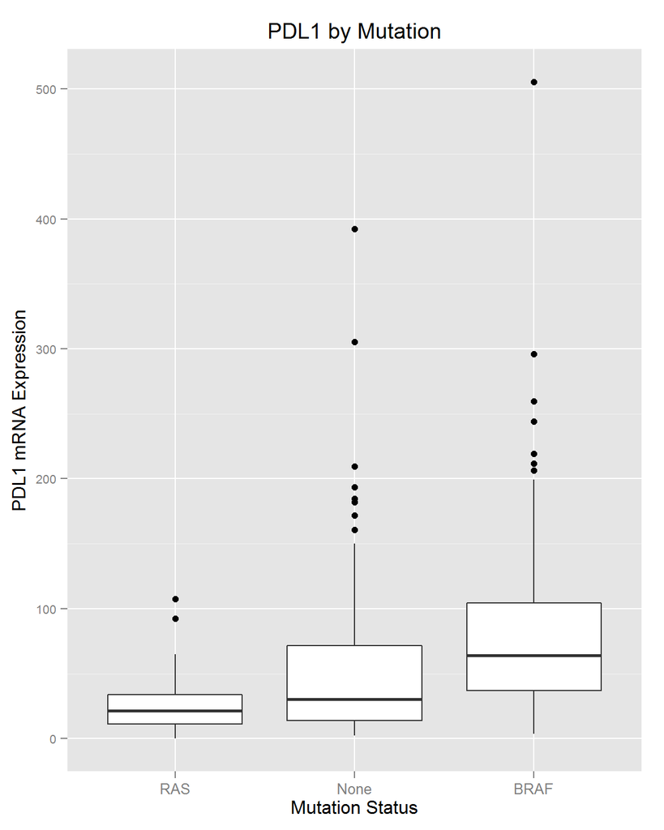

Kruskal Wallis test to see if any pairs are different: p-value = 4.257341710^{-15}

Since the p-value from Kruskal Wallis is significant, we will make pair-wise comparisons of the three groups using Wilcox-rank-sum test.

None vs. BRAF: p-value = 6.542141410^{-7}

None vs. RAS: p-value = 0.0071068

BRAF vs. RAS: p-value = 6.541576610^{-14}

All p-values are significant, therefore all groups are different from each other.

Is there a difference in PDL1 expression based on the different types of RAS mutations?

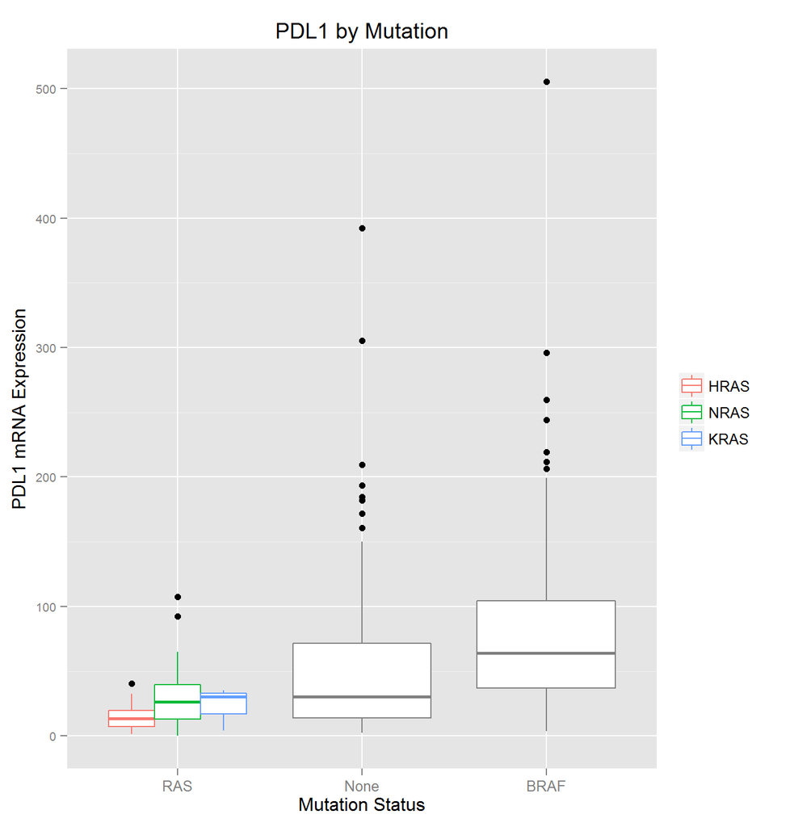

Kruskal Wallis test to see if RAS mutants are different from each other: p-value = 0.1081971

Because the p-value is not significant, we conclude that PDL1 expression is the same for all three different RAS mutations.